# Can efficient residual flipping calibrate SEM goodness of fit?

A small Foldnes–Moss–Gronneberg-style DGP probe

```
<environment: R_GlobalEnv>
```

## Result first

This probe implements a coherent GOF analogue of efficient score flipping. For every case, the saturated covariance contribution is centred at the fitted model and projected onto the expected-information complement of the model tangent. The all-plus quadratic is the structured RLS GOF statistic; random signs supply its reference distribution.

The optional standardized arm whitens those same projected contributions by their empirical covariance. It is therefore an operation on the efficient residual scores themselves. It is not the nested test’s flip-specific nuisance correction, because the GOF projection has already removed the nuisance tangent.

This report contains **100 replications per cell and 199 random flips**. The run is an exploratory probe, not a method-ranking simulation.

## Identity and availability checks

| check | value |
| --- | --- |
| replications | 1600 |
| failed fit/test batteries | 0 |
| largest \|flip statistic - RLS statistic\| | 1.17e-07 |
| standardization available | 1200/1600 |

| p | n | residual df | n/df | standardization availability |
| --- | --- | --- | --- | --- |
| 20 | 100 | 170 | 0.588 | 0 |
| 20 | 400 | 170 | 2.353 | 1 |
| 5 | 100 | 5 | 20.000 | 1 |
| 5 | 400 | 5 | 80.000 | 1 |

The unavailable corner is structural, not a software failure: at `p=20`, residual df is 170, so an unregularized empirical covariance cannot have full rank at `n=100`. No ridge or eigenvalue truncation is inserted. At `n=400` the matrix is invertible, but conditioning remains part of the result rather than being declared harmless.

## Design

| indicators | n | GOF df | n/df | omitted residual covariance under power |
| --- | --- | --- | --- | --- |
| 5 | 100 | 5 | 20.00 | 0.00 |
| 20 | 100 | 170 | 0.59 | 0.00 |
| 5 | 400 | 5 | 80.00 | 0.00 |
| 20 | 400 | 170 | 2.35 | 0.00 |
| 5 | 100 | 5 | 20.00 | 0.25 |
| 20 | 100 | 170 | 0.59 | 0.25 |
| 5 | 400 | 5 | 80.00 | 0.25 |
| 20 | 400 | 170 | 2.35 | 0.25 |

The null is a correctly specified one-factor covariance model. The power DGP adds one residual covariance of .25 between the first two indicators but fits the same CFA. Normal data are paired with the severe polynomial-logistic construction targeting marginal skewness 3 and excess kurtosis 21. There is no `t5` cell and no unbiased-Gamma variant.

## Null calibration retains the cells

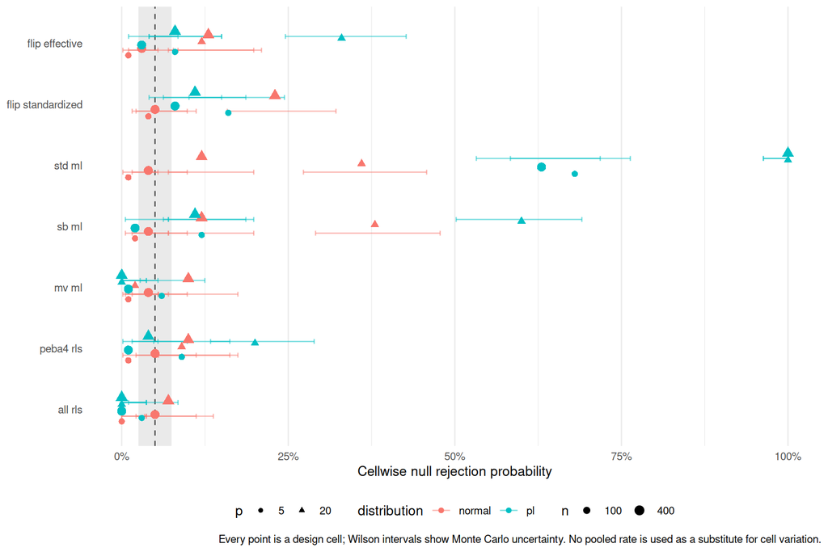

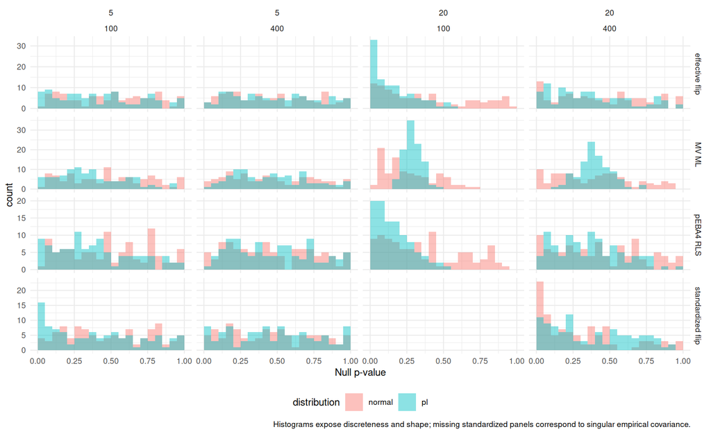

## When might standardization earn its keep?

| p | n | distribution | truth | empirical_eigen_min | empirical_eigen_mean | empirical_eigen_cv | empirical_eigen_ratio | empirical_identity_distance |
| --- | --- | --- | --- | --- | --- | --- | --- | --- |
| 5 | 100 | normal | null | 0.560 | 0.986 | 0.382 | 2.648 | 0.342 |
| 20 | 100 | normal | null | 0.000 | 1.002 | 1.557 | Inf | 1.554 |
| 5 | 400 | normal | null | 0.754 | 0.994 | 0.196 | 1.649 | 0.181 |
| 20 | 400 | normal | null | 0.099 | 1.001 | 0.780 | 36.808 | 0.777 |
| 5 | 100 | pl | null | 0.343 | 2.682 | 0.993 | 18.005 | 2.850 |
| 20 | 100 | pl | null | 0.000 | 3.195 | 4.390 | Inf | 14.185 |
| 5 | 400 | pl | null | 1.119 | 3.462 | 0.691 | 6.429 | 3.242 |
| 20 | 400 | pl | null | 0.002 | 3.851 | 2.689 | 42358.408 | 10.613 |
| 5 | 100 | normal | power | 0.548 | 1.002 | 0.419 | 2.872 | 0.375 |
| 20 | 100 | normal | power | 0.000 | 1.003 | 1.566 | Inf | 1.567 |
| 5 | 400 | normal | power | 0.694 | 1.017 | 0.283 | 1.998 | 0.260 |
| 20 | 400 | normal | power | 0.097 | 1.002 | 0.788 | 37.455 | 0.787 |
| 5 | 100 | pl | power | 0.323 | 2.998 | 1.037 | 20.842 | 3.504 |
| 20 | 100 | pl | power | 0.000 | 3.186 | 4.462 | Inf | 14.204 |
| 5 | 400 | pl | power | 1.112 | 3.655 | 0.735 | 6.743 | 3.634 |
| 20 | 400 | pl | power | 0.002 | 3.834 | 2.687 | 41943.230 | 10.534 |

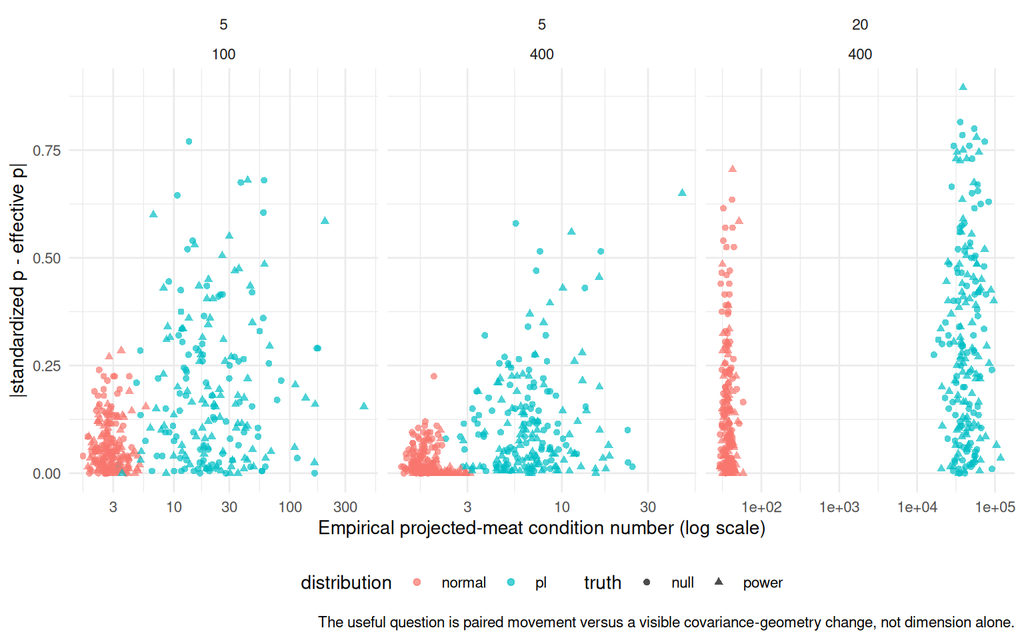

The a priori prediction is non-monotone. Standardization should have little to do under well-sampled normal theory, may help under nonnormal anisotropy, and becomes unstable or undefined as residual df approaches sample rank. The probe therefore treats availability and condition number as part of the method, not as implementation trivia.

## What this probe says

At `p=5`, effective-flip null rejection was 0.01/0.03 for normal `n=100/400` and 0.08/0.03 for PL. With only 100 replications the intervals are wide, but nothing here rules out useful low-rank calibration.

At `p=20` (df 170), the story changes. Effective rejection was 0.12/0.13 under normality and 0.33/0.08 under PL. Standardization was unavailable at `n=100`; at `n=400` it rejected 0.23/0.11 under normal/PL, versus the effective arm’s 0.13/0.08. The corresponding median empirical-meat condition numbers were about 37 and 42,000. That is evidence against treating raw empirical whitening as the automatic GOF analogue of nested-test standardization.

The high-rank failure is not unique to flipping. At `p=20,n=100`, ordinary ML and SB were badly liberal, whereas MV/SS/ALL were often extremely conservative under PL; pEBA4-RLS sat between those extremes but still rejected .20. The cellwise plot is the result: no pooled average should hide this geometry.

## Power

| p | n | df | distribution | method | n_null | n_power | nominal_power | matched_power | ci_lower | ci_upper |
| --- | --- | --- | --- | --- | --- | --- | --- | --- | --- | --- |
| 5 | 100 | 5 | normal | flip effective | 100 | 100 | 0.28 | 0.33 | 0.246 | 0.427 |
| 20 | 100 | 170 | normal | flip effective | 100 | 100 | 0.19 | 0.09 | 0.048 | 0.162 |
| 5 | 400 | 5 | normal | flip effective | 100 | 100 | 0.88 | 0.88 | 0.802 | 0.930 |
| 20 | 400 | 170 | normal | flip effective | 100 | 100 | 0.42 | 0.30 | 0.219 | 0.396 |
| 5 | 100 | 5 | pl | flip effective | 100 | 100 | 0.19 | 0.09 | 0.048 | 0.162 |
| 20 | 100 | 170 | pl | flip effective | 100 | 100 | 0.30 | 0.03 | 0.010 | 0.085 |
| 5 | 400 | 5 | pl | flip effective | 100 | 100 | 0.35 | 0.46 | 0.366 | 0.557 |
| 20 | 400 | 170 | pl | flip effective | 100 | 100 | 0.19 | 0.14 | 0.085 | 0.221 |
| 5 | 100 | 5 | normal | flip standardized | 100 | 100 | 0.25 | 0.25 | 0.175 | 0.343 |
| 5 | 400 | 5 | normal | flip standardized | 100 | 100 | 0.85 | 0.77 | 0.678 | 0.842 |
| 20 | 400 | 170 | normal | flip standardized | 100 | 100 | 0.44 | 0.00 | 0.000 | 0.037 |
| 5 | 100 | 5 | pl | flip standardized | 100 | 100 | 0.19 | 0.03 | 0.010 | 0.085 |
| 5 | 400 | 5 | pl | flip standardized | 100 | 100 | 0.34 | 0.26 | 0.184 | 0.354 |
| 20 | 400 | 170 | pl | flip standardized | 100 | 100 | 0.18 | 0.04 | 0.016 | 0.098 |
| 5 | 100 | 5 | normal | all rls | 100 | 100 | 0.25 | 0.33 | 0.246 | 0.427 |
| 20 | 100 | 170 | normal | all rls | 100 | 100 | 0.01 | 0.09 | 0.048 | 0.162 |
| 5 | 400 | 5 | normal | all rls | 100 | 100 | 0.89 | 0.89 | 0.814 | 0.937 |
| 20 | 400 | 170 | normal | all rls | 100 | 100 | 0.26 | 0.26 | 0.184 | 0.354 |
| 5 | 100 | 5 | pl | all rls | 100 | 100 | 0.06 | 0.10 | 0.055 | 0.174 |
| 20 | 100 | 170 | pl | all rls | 100 | 100 | 0.00 | 0.06 | 0.028 | 0.125 |
| 5 | 400 | 5 | pl | all rls | 100 | 100 | 0.25 | 0.42 | 0.328 | 0.518 |
| 20 | 400 | 170 | pl | all rls | 100 | 100 | 0.00 | 0.14 | 0.085 | 0.221 |
| 5 | 100 | 5 | normal | mv ml | 100 | 100 | 0.27 | 0.34 | 0.255 | 0.437 |
| 20 | 100 | 170 | normal | mv ml | 100 | 100 | 0.09 | 0.14 | 0.085 | 0.221 |
| 5 | 400 | 5 | normal | mv ml | 100 | 100 | 0.88 | 0.88 | 0.802 | 0.930 |
| 20 | 400 | 170 | normal | mv ml | 100 | 100 | 0.32 | 0.26 | 0.184 | 0.354 |
| 5 | 100 | 5 | pl | mv ml | 100 | 100 | 0.11 | 0.07 | 0.034 | 0.137 |
| 20 | 100 | 170 | pl | mv ml | 100 | 100 | 0.00 | 0.02 | 0.006 | 0.070 |
| 5 | 400 | 5 | pl | mv ml | 100 | 100 | 0.23 | 0.42 | 0.328 | 0.518 |
| 20 | 400 | 170 | pl | mv ml | 100 | 100 | 0.00 | 0.12 | 0.070 | 0.198 |
| 5 | 100 | 5 | normal | peba4 rls | 100 | 100 | 0.30 | 0.33 | 0.246 | 0.427 |
| 20 | 100 | 170 | normal | peba4 rls | 100 | 100 | 0.16 | 0.09 | 0.048 | 0.162 |
| 5 | 400 | 5 | normal | peba4 rls | 100 | 100 | 0.89 | 0.89 | 0.814 | 0.937 |
| 20 | 400 | 170 | normal | peba4 rls | 100 | 100 | 0.38 | 0.26 | 0.184 | 0.354 |
| 5 | 100 | 5 | pl | peba4 rls | 100 | 100 | 0.15 | 0.08 | 0.041 | 0.150 |
| 20 | 100 | 170 | pl | peba4 rls | 100 | 100 | 0.20 | 0.07 | 0.034 | 0.137 |
| 5 | 400 | 5 | pl | peba4 rls | 100 | 100 | 0.31 | 0.42 | 0.328 | 0.518 |
| 20 | 400 | 170 | pl | peba4 rls | 100 | 100 | 0.14 | 0.14 | 0.085 | 0.221 |
| 5 | 100 | 5 | normal | sb ml | 100 | 100 | 0.29 | 0.34 | 0.255 | 0.437 |
| 20 | 100 | 170 | normal | sb ml | 100 | 100 | 0.47 | 0.15 | 0.093 | 0.233 |
| 5 | 400 | 5 | normal | sb ml | 100 | 100 | 0.88 | 0.88 | 0.802 | 0.930 |
| 20 | 400 | 170 | normal | sb ml | 100 | 100 | 0.47 | 0.25 | 0.175 | 0.343 |
| 5 | 100 | 5 | pl | sb ml | 100 | 100 | 0.21 | 0.09 | 0.048 | 0.162 |
| 20 | 100 | 170 | pl | sb ml | 100 | 100 | 0.62 | 0.05 | 0.022 | 0.112 |
| 5 | 400 | 5 | pl | sb ml | 100 | 100 | 0.35 | 0.39 | 0.300 | 0.488 |
| 20 | 400 | 170 | pl | sb ml | 100 | 100 | 0.19 | 0.15 | 0.093 | 0.233 |
| 5 | 100 | 5 | normal | std ml | 100 | 100 | 0.27 | 0.39 | 0.300 | 0.488 |
| 20 | 100 | 170 | normal | std ml | 100 | 100 | 0.46 | 0.12 | 0.070 | 0.198 |
| 5 | 400 | 5 | normal | std ml | 100 | 100 | 0.89 | 0.90 | 0.826 | 0.945 |
| 20 | 400 | 170 | normal | std ml | 100 | 100 | 0.47 | 0.25 | 0.175 | 0.343 |
| 5 | 100 | 5 | pl | std ml | 100 | 100 | 0.79 | 0.12 | 0.070 | 0.198 |
| 20 | 100 | 170 | pl | std ml | 100 | 100 | 1.00 | 0.05 | 0.022 | 0.112 |
| 5 | 400 | 5 | pl | std ml | 100 | 100 | 0.92 | 0.37 | 0.282 | 0.468 |
| 20 | 400 | 170 | pl | std ml | 100 | 100 | 1.00 | 0.13 | 0.078 | 0.210 |

Matched power calibrates each method against its empirical null p-values in the same `(p,n,distribution)` corner. With a small probe it is noisy, but it keeps size distortion from masquerading as power. The single omitted covariance is also deliberately sparse: dilution in the 170-dimensional residual space is a feature of the question.

## Timing

| p | n | median_seconds.draw | median_seconds.fit | median_seconds.flip_score | median_seconds.flip_setup | median_seconds.flip_standardization | median_seconds.flip_total | median_seconds.fmg_battery | median_seconds.replication_total | median_seconds.standardization_setup |
| --- | --- | --- | --- | --- | --- | --- | --- | --- | --- | --- |
| 5 | 100 | 0 | 0.001 | 0.000 | 0.000 | 0.000 | 0.001 | 0.0020 | 0.0045 | 0.000 |
| 20 | 100 | 0 | 0.002 | 0.001 | 0.002 | 0.000 | 0.007 | 0.0375 | 0.0475 | 0.004 |
| 5 | 400 | 0 | 0.001 | 0.001 | 0.000 | 0.000 | 0.002 | 0.0020 | 0.0055 | 0.000 |
| 20 | 400 | 0 | 0.002 | 0.005 | 0.005 | 0.002 | 0.018 | 0.0330 | 0.0552 | 0.007 |

One-time generator setup, shared across n=100 and n=400

| p | distribution | truth | setup_seconds | error |
| --- | --- | --- | --- | --- |
| 5 | normal | null | 0.013 | NA |
| 20 | normal | null | 0.037 | NA |
| 5 | pl | null | 1.395 | NA |
| 20 | pl | null | 22.820 | NA |
| 5 | normal | power | 0.014 | NA |
| 20 | normal | power | 0.034 | NA |
| 5 | pl | power | 0.887 | NA |
| 20 | pl | power | 18.871 | NA |

The relevant incremental cost is `standardization_setup + flip_standardization`, not the whole model fit. Unlike the nested flip-specific correction, this empirical whitening is computed once and reused for all signs; its statistical conditioning is expected to become a problem before its arithmetic cost does. Polynomial-logistic calibration is the dominant one-time setup at `p=20` and is kept outside replication timing. For this 100-replication run, the four-worker wall time was 36.4 seconds. At `p=20,n=400`, the median replication took about 55 ms: 5 ms for effective flip resampling, 7 ms to factor the empirical standardizer, 2 ms to apply it over the flips, and 33 ms for the 12-test FMG battery. Arithmetic cost is modest; statistical instability is the binding issue.

## Decision after the probe

The algebraic bridge is sound and the low-rank cells justify another focused look. The present gate does **not** justify a general core default: effective flipping deteriorated when residual rank was large relative to sample size, and raw empirical standardization was unavailable or worse. The next probe should stay at low/moderate df, increase the null budget, and vary `n/df` directly. If rescuing high-df cells requires a shrinkage parameter, that is a separate method-selection problem—not a free extension of sign flipping.